# Rural vs Urban Regression

(Austin Mercado, Ryan Alvarez, Itzel Bayon, Pamela Diaz, and Seshah Eshete)

02 December, 2022

** Required to run code/read excel files

# Data Source 1 &2

```r
UCM_Regression <- readxl::read_xlsx("UCMerced.xlsx")
UCLA_Regression <- readxl::read_xlsx("UCLA.xlsx")
MIX_2 <- readxl::read_xlsx("Mix Data.xlsx")
MIX_2$Area<-as.factor(MIX_2$Area)
```

# MEAN/MEDIAN/STANDARD DEVIATION FOR THE UCM: Years 2-6 Graduation Rates

*Overall Data

```r
str(UCM_Regression)
```

```
## tibble [18 × 24] (S3: tbl_df/tbl/data.frame)
##  $ Entry Fall              : num [1:18] 2005 2006 2007 2008 2009 ...
##  $ Size                    : num [1:18] 706 396 668 922 1125 ...
##  $ 1st Year Graduated      : logi [1:18] NA NA NA NA NA NA ...
##  $ 2nd Year Returned       : num [1:18] 581 315 529 766 980 ...
##  $ 2nd Year Retention Rate : num [1:18] 0.82 0.8 0.79 0.83 0.87 0.85 0.83 0.84 0.83 0.84 ...
##  $ 2nd Year Graduated      : num [1:18] 0 0 1 0 0 0 1 1 1 0 ...
##  $ 2nd Year Graduation Rate: num [1:18] 0 0 0 0 0 0 0 0 0 0 ...
##  $ 3rd Year Returned       : num [1:18] 482 272 447 684 848 ...
##  $ 3rd Year Retention Rate : num [1:18] 0.68 0.69 0.67 0.74 0.75 0.74 0.73 0.73 0.75 0.74 ...
##  $ 3rd Year Graduated      : num [1:18] 9 3 7 12 15 21 24 18 18 24 ...
##  $ 3rd Year Graduation Rate: num [1:18] 0.01 0.01 0.01 0.01 0.01 0.02 0.01 0.01 0.02 0.02 ...
##  $ 4th Year Returned       : num [1:18] 448 257 414 632 803 ...
##  $ 4th Year Retention Rate : num [1:18] 0.63 0.65 0.62 0.69 0.71 0.7 0.68 0.69 0.71 0.69 ...
##  $ 4th Year Graduated      : num [1:18] 235 118 179 310 413 502 468 565 737 690 ...
##  $ 4th Year Graduation Rate: num [1:18] 0.33 0.3 0.27 0.34 0.37 0.38 0.33 0.38 0.45 0.45 ...
##  $ 5th Year Returned       : num [1:18] 177 113 204 283 359 419 482 427 423 376 ...
##  $ 5th Year Retention Rate : num [1:18] 0.25 0.29 0.31 0.31 0.32 0.31 0.33 0.29 0.26 0.24 ...
##  $ 5th Year Graduated      : num [1:18] 369 201 328 510 695 ...
##  $ 5th Year Graduation Rate: num [1:18] 0.52 0.51 0.49 0.55 0.62 0.63 0.6 0.62 0.66 0.66 ...
##  $ 6th Year Returned       : num [1:18] 38 34 51 78 56 51 66 64 58 52 ...
##  $ 6th Year Retention Rate : num [1:18] 0.05 0.09 0.08 0.08 0.05 0.04 0.05 0.04 0.04 0.03 ...
##  $ 6th Year Graduated      : num [1:18] 411 230 379 586 747 ...
##  $ 6th Year Graduation Rate: num [1:18] 0.58 0.58 0.57 0.64 0.66 0.66 0.64 0.66 0.69 0.69 ...
##  $ Location                : chr [1:18] "Rural" "Rural" "Rural" "Rural" ...
```

*2nd Fall Graduated

```r
UCM_Regression |>
  summarize(xbar = mean(`2nd Year Graduation Rate`, na.rm = TRUE),
            median = median(`2nd Year Graduation Rate`, na.rm = TRUE),
            s = sd(`2nd Year Graduation Rate`, na.rm = TRUE))
```

```
## # A tibble: 1 × 3
##    xbar median     s
##   <dbl>  <dbl> <dbl>
## 1     0      0     0
```

*3rd Fall Graduated

```r
UCM_Regression |>
  summarize(xbar = mean(`3rd Year Graduation Rate`, na.rm = TRUE),
            median = median(`3rd Year Graduation Rate`, na.rm = TRUE),
            s = sd(`3rd Year Graduation Rate`, na.rm = TRUE))
```

```
## # A tibble: 1 × 3
##    xbar median       s
##   <dbl>  <dbl>   <dbl>
## 1 0.015   0.01 0.00650
```

*4th Fall Graduated

```r
UCM_Regression |>
  summarize(xbar = mean(`4th Year Graduation Rate`, na.rm = TRUE),
            median = median(`4th Year Graduation Rate`, na.rm = TRUE),
            s = sd(`4th Year Graduation Rate`, na.rm = TRUE))
```

```
## # A tibble: 1 × 3
##    xbar median      s
##   <dbl>  <dbl>  <dbl>
## 1 0.394   0.38 0.0758
```

*5th Fall Graduated

```r
UCM_Regression |>
  summarize(xbar = mean(`5th Year Graduation Rate`, na.rm = TRUE),
            median = median(`5th Year Graduation Rate`, na.rm = TRUE),
            s = sd(`5th Year Graduation Rate`, na.rm = TRUE))
```

```
## # A tibble: 1 × 3
##    xbar median      s
##   <dbl>  <dbl>  <dbl>
## 1 0.603   0.62 0.0642
```

*6th Fall Graduated

```r
UCM_Regression |>
  summarize(xbar = mean(`6th Year Graduation Rate`, na.rm = TRUE),
            median = median(`6th Year Graduation Rate`, na.rm = TRUE),
            s = sd(`6th Year Graduation Rate`, na.rm = TRUE))
```

```
## # A tibble: 1 × 3
##    xbar median      s
##   <dbl>  <dbl>  <dbl>
## 1 0.647   0.66 0.0477
```

# MEAN/MEDIAN/STANDARD DEVIATION FOR THE UCM: Years 2-6 Returned Rates

*2nd Fall Returned

```r
UCM_Regression |>
  summarize(xbar = mean(`2nd Year Retention Rate`, na.rm = TRUE),
            median = median(`2nd Year Retention Rate`, na.rm = TRUE),
            s = sd(`2nd Year Retention Rate`, na.rm = TRUE))
```

```
## # A tibble: 1 × 3
##    xbar median      s
##   <dbl>  <dbl>  <dbl>
## 1 0.829   0.83 0.0244
```

*3rd Fall Returned

```r
UCM_Regression |>
  summarize(xbar = mean(`3rd Year Retention Rate`, na.rm = TRUE),
            median = median(`3rd Year Retention Rate`, na.rm = TRUE),
            s = sd(`3rd Year Retention Rate`, na.rm = TRUE))
```

```
## # A tibble: 1 × 3
##    xbar median      s
##   <dbl>  <dbl>  <dbl>
## 1 0.728  0.735 0.0328
```

*4th Fall Returned

```r
UCM_Regression |>
  summarize(xbar = mean(`4th Year Retention Rate`, na.rm = TRUE),
            median = median(`4th Year Retention Rate`, na.rm = TRUE),
            s = sd(`4th Year Retention Rate`, na.rm = TRUE))
```

```
## # A tibble: 1 × 3
##    xbar median      s
##   <dbl>  <dbl>  <dbl>
## 1 0.685   0.69 0.0304
```

*5th Fall Returned

```r
UCM_Regression |>
  summarize(xbar = mean(`5th Year Retention Rate`, na.rm = TRUE),
            median = median(`5th Year Retention Rate`, na.rm = TRUE),
            s = sd(`5th Year Retention Rate`, na.rm = TRUE))
```

```
## # A tibble: 1 × 3
##    xbar median      s
##   <dbl>  <dbl>  <dbl>
## 1 0.273  0.275 0.0414
```

*6th Fall Returned

```r
UCM_Regression |>
  summarize(xbar = mean(`6th Year Retention Rate`, na.rm = TRUE),
            median = median(`6th Year Retention Rate`, na.rm = TRUE),
            s = sd(`6th Year Retention Rate`, na.rm = TRUE))
```

```
## # A tibble: 1 × 3
##     xbar median      s
##    <dbl>  <dbl>  <dbl>
## 1 0.0508   0.04 0.0198
```

# MEAN/MEDIAN/STANDARD DEVIATION FOR THE UCLA Year: 2-6 Graduation Rates

*Overall Data

```r
str(UCLA_Regression)
```

```
## tibble [18 × 24] (S3: tbl_df/tbl/data.frame)
##  $ Entry Fall              : num [1:18] 2005 2006 2007 2008 2009 ...
##  $ Size                    : num [1:18] 4422 4808 4562 4735 4470 ...
##  $ 1st Year Graduated      : logi [1:18] NA NA NA NA NA NA ...
##  $ 2nd Fall Returned       : num [1:18] 4275 4670 4412 4571 4330 ...
##  $ 2nd Year Retention Rate : num [1:18] 0.967 0.971 0.967 0.965 0.969 ...
##  $ 2nd Year Graduated      : num [1:18] 6 3 1 5 6 4 4 3 4 2 ...
##  $ 2nd Year Graduation Rate: num [1:18] 0.001357 0.000624 0.000219 0.001056 0.001342 ...
##  $ 3rd Fall Returned       : num [1:18] 4038 4445 4207 4341 4130 ...
##  $ 3rd Year Retention Rate : num [1:18] 0.913 0.925 0.922 0.917 0.924 ...
##  $ 3rd Year Graduated      : num [1:18] 139 119 145 174 125 123 190 192 180 211 ...
##  $ 3rd Year Graduation Rate: num [1:18] 0.0314 0.0248 0.0318 0.0367 0.028 ...
##  $ 4th Fall Returned       : num [1:18] 3935 4344 4062 4206 4003 ...
##  $ 4th Year Retention Rate : num [1:18] 0.89 0.903 0.89 0.888 0.896 ...
##  $ 4th Year Graduated      : num [1:18] 2992 3416 3152 3448 3295 ...
##  $ 4th Year Graduation Rate: num [1:18] 0.677 0.71 0.691 0.728 0.737 ...
##  $ 5th Year Returned       : num [1:18] 997 902 924 820 739 741 870 757 656 568 ...
##  $ 5th Year Retention Rate : num [1:18] 0.225 0.188 0.203 0.173 0.165 ...
##  $ 5th Year Graduated      : num [1:18] 3891 4318 4038 4231 4013 ...
##  $ 5th Year Graduation Rate: num [1:18] 0.88 0.898 0.885 0.894 0.898 ...
##  $ 6th Fall Returned       : num [1:18] 82 79 115 83 94 83 130 118 100 82 ...
##  $ 6th Year Retention Rate : num [1:18] 0.0185 0.0164 0.0252 0.0175 0.021 ...
##  $ 6th Year Graduated      : num [1:18] 3996 4421 4134 4319 4082 ...
##  $ 6th Year Graduation Rate: num [1:18] 0.904 0.92 0.906 0.912 0.913 ...
##  $ Location                : chr [1:18] "Urban" "Urban" "Urban" "Urban" ...
```

*2nd Fall Graduated

```r
UCLA_Regression |>
  summarize(xbar = mean(`2nd Year Graduation Rate`, na.rm = TRUE),
            median = median(`2nd Year Graduation Rate`, na.rm = TRUE),
            s = sd(`2nd Year Graduation Rate`, na.rm = TRUE))
```

```
## # A tibble: 1 × 3
##      xbar   median        s
##     <dbl>    <dbl>    <dbl>
## 1 0.00111 0.000960 0.000691
```

*3rd Fall Graduated

```r
UCLA_Regression |>
  summarize(xbar = mean(`3rd Year Graduation Rate`, na.rm = TRUE),
            median = median(`3rd Year Graduation Rate`, na.rm = TRUE),
            s = sd(`3rd Year Graduation Rate`, na.rm = TRUE))
```

```
## # A tibble: 1 × 3
##     xbar median      s
##    <dbl>  <dbl>  <dbl>
## 1 0.0366 0.0331 0.0104
```

*4th Fall Graduated

```r
UCLA_Regression |>
  summarize(xbar = mean(`4th Year Graduation Rate`, na.rm = TRUE),
            median = median(`4th Year Graduation Rate`, na.rm = TRUE),
            s = sd(`4th Year Graduation Rate`, na.rm = TRUE))
```

```
## # A tibble: 1 × 3
##    xbar median      s
##   <dbl>  <dbl>  <dbl>
## 1 0.770  0.757 0.0600
```

*5th Fall Graduated

```r
UCLA_Regression |>
  summarize(xbar = mean(`5th Year Graduation Rate`, na.rm = TRUE),
            median = median(`5th Year Graduation Rate`, na.rm = TRUE),
            s = sd(`5th Year Graduation Rate`, na.rm = TRUE))
```

```
## # A tibble: 1 × 3
##    xbar median      s
##   <dbl>  <dbl>  <dbl>
## 1 0.898  0.898 0.0104
```

```r
UCLA_Regression |>
  summarize(xbar = mean(`6th Year Graduated`, na.rm = TRUE),
            median = median(`6th Year Graduated`, na.rm = TRUE),
            s = sd(`6th Year Graduated`, na.rm = TRUE))
```

```
## # A tibble: 1 × 3
##    xbar median     s
##   <dbl>  <dbl> <dbl>
## 1 4778.  4754.  656.
```

# MEAN/MEDIAN/STANDARD DEVIATION FOR THE UCLA Year: 2-6 Returned

*2nd Fall Returned

```r
UCLA_Regression |>
  summarize(xbar = mean(`2nd Fall Returned`, na.rm = TRUE),
            median = median(`2nd Fall Returned`, na.rm = TRUE),
            s = sd(`2nd Fall Returned`, na.rm = TRUE))
```

```
## # A tibble: 1 × 3
##    xbar median     s
##   <dbl>  <dbl> <dbl>
## 1 5336.   5513  728.
```

*3rd Fall Returned

```r
UCLA_Regression |>
  summarize(xbar = mean(`3rd Fall Returned`, na.rm = TRUE),
            median = median(`3rd Fall Returned`, na.rm = TRUE),
            s = sd(`3rd Fall Returned`, na.rm = TRUE))
```

```
## # A tibble: 1 × 3
##    xbar median     s
##   <dbl>  <dbl> <dbl>
## 1 5077.  5308.  716.
```

*4th Fall Returned

```r
UCLA_Regression |>
  summarize(xbar = mean(`4th Fall Returned`, na.rm = TRUE),
            median = median(`4th Fall Returned`, na.rm = TRUE),
            s = sd(`4th Fall Returned`, na.rm = TRUE))
```

```
## # A tibble: 1 × 3
##    xbar median     s
##   <dbl>  <dbl> <dbl>
## 1 4781.   5054  600.
```

*5th Fall Returned

```r
UCLA_Regression |>
  summarize(xbar = mean(`5th Year Returned`, na.rm = TRUE),
            median = median(`5th Year Returned`, na.rm = TRUE),
            s = sd(`5th Year Returned`, na.rm = TRUE))
```

```
## # A tibble: 1 × 3
##    xbar median     s
##   <dbl>  <dbl> <dbl>
## 1  696.    740  199.
```

*6th Fall Returned

```r
UCLA_Regression |>
  summarize(xbar = mean(`6th Fall Returned`, na.rm = TRUE),
            median = median(`6th Fall Returned`, na.rm = TRUE),
            s = sd(`6th Fall Returned`, na.rm = TRUE))
```

```
## # A tibble: 1 × 3
##    xbar median     s
##   <dbl>  <dbl> <dbl>
## 1  91.4     83  19.3
```

#GG Plots

```r
head(MIX_2)
```

```
## # A tibble: 6 × 24
##   Entry …¹  Size 1st Y…² 2nd F…³ 2nd Y…⁴ 2nd Y…⁵ 2nd Y…⁶ 3rd F…⁷ 3rd Y…⁸ 3rd Y…⁹
##      <dbl> <dbl> <lgl>     <dbl>   <dbl>   <dbl>   <dbl>   <dbl>   <dbl>   <dbl>
## 1     2005  4422 NA         4275   0.967       6 1.36e-3    4038   0.913     139
## 2     2006  4808 NA         4670   0.971       3 6.24e-4    4445   0.925     119
## 3     2007  4562 NA         4412   0.967       1 2.19e-4    4207   0.922     145
## 4     2008  4735 NA         4571   0.965       5 1.06e-3    4341   0.917     174
## 5     2009  4470 NA         4330   0.969       6 1.34e-3    4130   0.924     125
## 6     2010  4633 NA         4486   0.968       4 8.63e-4    4298   0.928     123
## # … with 14 more variables: `3rd Year Graduation Rate` <dbl>,
## #   `4th Fall Returned` <dbl>, `4th Year Retention Rate` <dbl>,
## #   `4th Year Graduated` <dbl>, `4th Year Graduation Rate` <dbl>,
## #   `5th Year Returned` <dbl>, `5th Year Retention Rate` <dbl>,
## #   `5th Year Graduated` <dbl>, `5th Year Graduation Rate` <dbl>,
## #   `6th Fall Returned` <dbl>, `6th Year Retention Rate` <dbl>,
## #   `6th Year Graduated` <dbl>, `6th Year Graduation Rate` <dbl>, Area <fct>, …
```

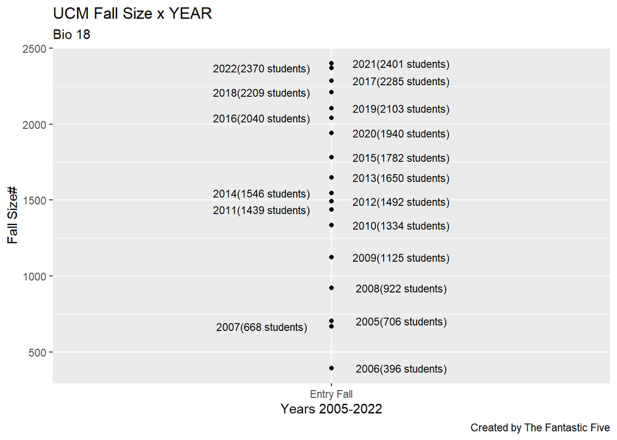

```r
MIX_2  %>%
    filter(Area == "Rural") %>%
    ggplot(aes(x = 'Entry Fall', y = Size)) +
    geom_point() +
    annotate("text", x = 1.15, y = 706, label= "2005(706 students)", size = 3) +
    annotate("text", x = 1.15, y = 396, label= "2006(396 students)", size = 3) +
    annotate("text", x = 0.85, y = 668, label= "2007(668 students)", size = 3) +
    annotate("text", x = 1.15, y = 922, label= "2008(922 students)", size = 3) +
    annotate("text", x = 1.15, y = 1125, label= "2009(1125 students)", size = 3) +
    annotate("text", x = 1.15, y = 1334, label= "2010(1334 students)", size = 3) +
    annotate("text", x = 0.85, y = 1439, label= "2011(1439 students)", size = 3) +
    annotate("text", x = 1.15, y = 1492, label= "2012(1492 students)", size = 3) +
    annotate("text", x = 1.15, y = 1650, label= "2013(1650 students)", size = 3) +
    annotate("text", x = 0.85, y = 1546, label= "2014(1546 students)", size = 3) +
    annotate("text", x = 1.15, y = 1782, label= "2015(1782 students)", size = 3) +
    annotate("text", x = 0.85, y = 2040, label= "2016(2040 students)", size = 3) +
    annotate("text", x = 1.15, y = 2285, label= "2017(2285 students)", size = 3) +
    annotate("text", x = 0.85, y = 2209, label= "2018(2209 students)", size = 3) +
    annotate("text", x = 1.15, y = 2103, label= "2019(2103 students)", size = 3) +
    annotate("text", x = 1.15, y = 1940, label= "2020(1940 students)", size = 3) +
    annotate("text", x = 1.15, y = 2401, label= "2021(2401 students)", size = 3) +
    annotate("text", x = 0.85, y = 2370, label= "2022(2370 students)", size = 3) +
    labs(title = "UCM Fall Size x YEAR",
       subtitle = "Bio 18", caption = "Created by The Fantastic Five" , x = "Years 2005-2022", y = "Fall Size#")
```

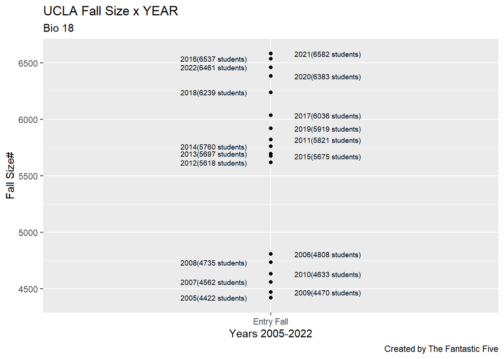

```r
MIX_2  %>%
    filter(Area == "Urban") %>%
    ggplot(aes(x = 'Entry Fall', y = Size)) +
    geom_point() +
    annotate("text", x = 0.85, y = 4422, label= "2005(4422 students)", size = 2.5) +
    annotate("text", x = 1.15, y = 4808, label= "2006(4808 students)", size = 2.5) +
    annotate("text", x = 0.85, y = 4562, label= "2007(4562 students)", size = 2.5) +
    annotate("text", x = 0.85, y = 4735, label= "2008(4735 students)", size = 2.5) +
    annotate("text", x = 1.15, y = 4470, label= "2009(4470 students)", size = 2.5) +
    annotate("text", x = 1.15, y = 4633, label= "2010(4633 students)", size = 2.5) +
    annotate("text", x = 1.15, y = 5821, label= "2011(5821 students)", size = 2.5) +
    annotate("text", x = 0.85, y = 5618, label= "2012(5618 students)", size = 2.5) +
    annotate("text", x = 0.85, y = 5697, label= "2013(5697 students)", size = 2.5) +
    annotate("text", x = 0.85, y = 5760, label= "2014(5760 students)", size = 2.5) +
    annotate("text", x = 1.15, y = 5675, label= "2015(5675 students)", size = 2.5) +
    annotate("text", x = 0.85, y = 6537, label= "2016(6537 students)", size = 2.5) +
    annotate("text", x = 1.15, y = 6036, label= "2017(6036 students)", size = 2.5) +
    annotate("text", x = 0.85, y = 6239, label= "2018(6239 students)", size = 2.5) +
    annotate("text", x = 1.15, y = 5919, label= "2019(5919 students)", size = 2.5) +
    annotate("text", x = 1.15, y = 6383, label= "2020(6383 students)", size = 2.5) +
    annotate("text", x = 1.15, y = 6582, label= "2021(6582 students)", size = 2.5) +
    annotate("text", x = 0.85, y = 6461, label= "2022(6461 students)", size = 2.5) + ylim(4400,6600) +
    labs(title = "UCLA Fall Size x YEAR",
       subtitle = "Bio 18", caption = "Created by The Fantastic Five" , x = "Years 2005-2022",  y = "Fall Size#")
```

##Maps of UCM and UCLA(For Appearance)

```r
map_plot <- leaflet() %>%
  addTiles()%>%
  setView(-120.4235, 37.366, zoom = 15)
```

```r
map_plot
```

[interactive chart not shown]

```r
map_plot2 <- leaflet() %>%
  addTiles()%>%
  setView(-118.439789907, 34.06999972, zoom = 15)
```

```r
map_plot2
```

[interactive chart not shown]

##Confidence Intervals for UCM

*Confidence Interval for 2nd Year Retention Rate

```r
# bootstrap distribution
UCM_BS2 <- UCM_Regression %>%
  specify(response = `2nd Year Retention Rate`) %>%
  generate(reps = 1000, type = "bootstrap") %>%
  calculate(stat = "mean")
UCM_BS2 %>%
  get_confidence_interval(level = 0.95, type = "percentile")
```

```
## # A tibble: 1 × 2
##   lower_ci upper_ci
##      <dbl>    <dbl>
## 1    0.818    0.841
```

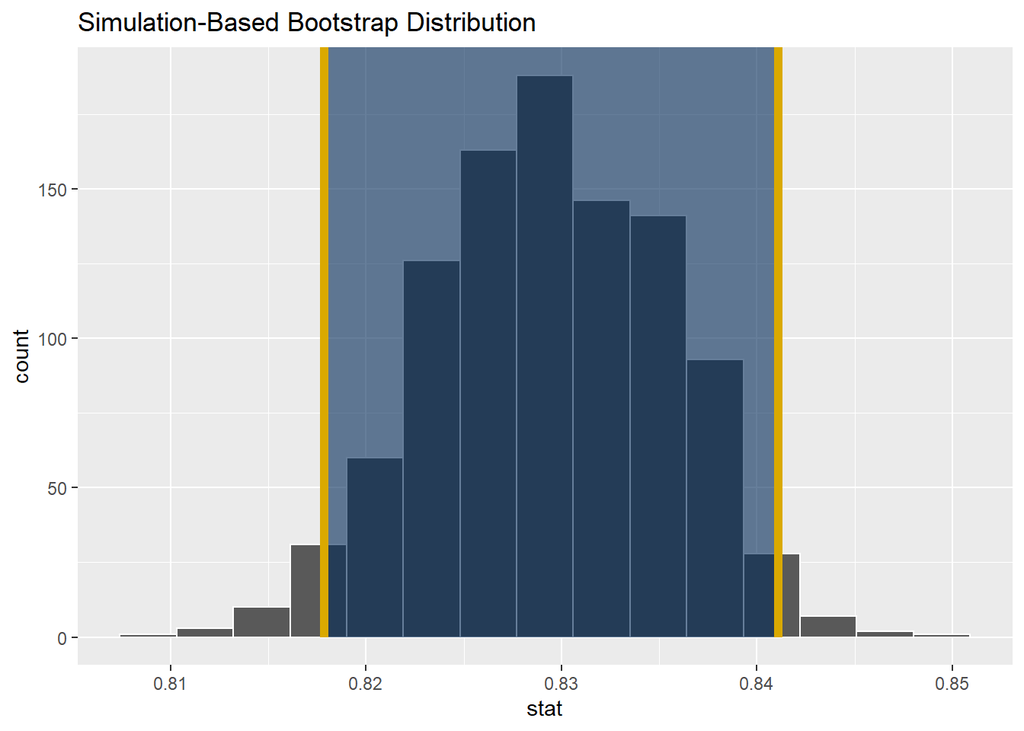

```r
UCM_BS2_1 <- UCM_BS2 %>%
  get_ci(point_estimate = mean(UCM_BS2$stat),
         level = 0.95, type = "se")

visualize(UCM_BS2) +
  shade_ci(endpoints = UCM_BS2_1, color = "#DAA900", fill = "#002856")
```

```r
#Alright Confidence Levels x>80
```

*Confidence Interval for 3rd Year Retention Rate

```r
# bootstrap distribution
UCM_BS3 <- UCM_Regression %>%
  specify(response = `3rd Year Retention Rate`) %>%
  generate(reps = 1000, type = "bootstrap") %>%
  calculate(stat = "mean")
UCM_BS3 %>%
  get_confidence_interval(level = 0.95, type = "percentile")
```

```
## # A tibble: 1 × 2
##   lower_ci upper_ci
##      <dbl>    <dbl>
## 1    0.711    0.742
```

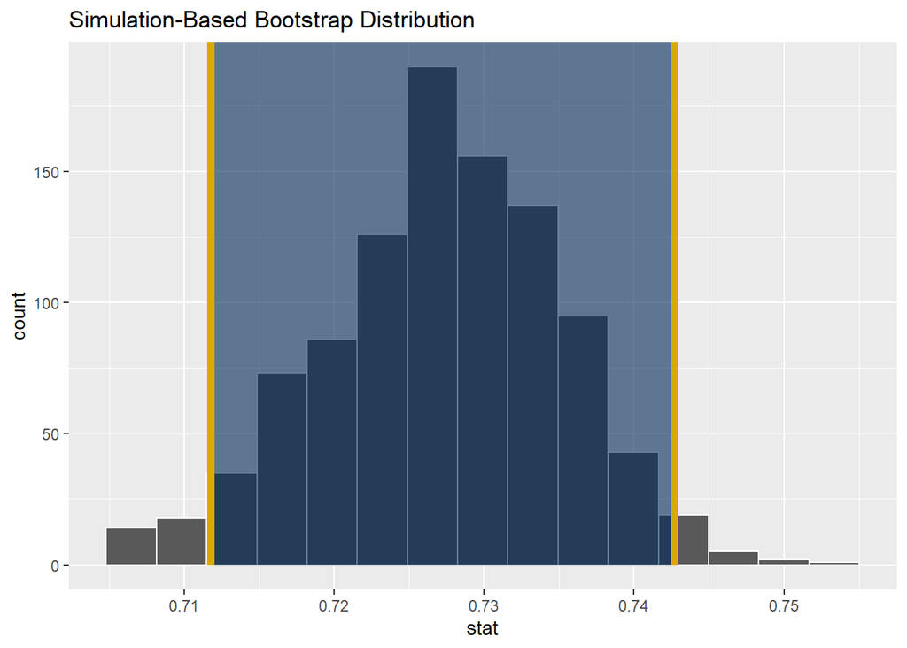

```r
UCM_BS3_2 <- UCM_BS3 %>%
  get_ci(point_estimate = mean(UCM_BS3$stat),
         level = 0.95, type = "se")

visualize(UCM_BS3) +
  shade_ci(endpoints = UCM_BS3_2, color = "#DAA900", fill = "#002856")
```

*Confidence Interval for 4th Year Retention Rate

```r
# bootstrap distribution
UCM_BS4 <- UCM_Regression %>%
  specify(response = `4th Year Retention Rate`) %>%
  generate(reps = 1000, type = "bootstrap") %>%
  calculate(stat = "mean")
#Ok Confidence Levels x>70
```

```r
UCM_BS4 %>%
  get_confidence_interval(level = 0.95, type = "percentile")
```

```
## # A tibble: 1 × 2
##   lower_ci upper_ci
##      <dbl>    <dbl>
## 1    0.669    0.699
```

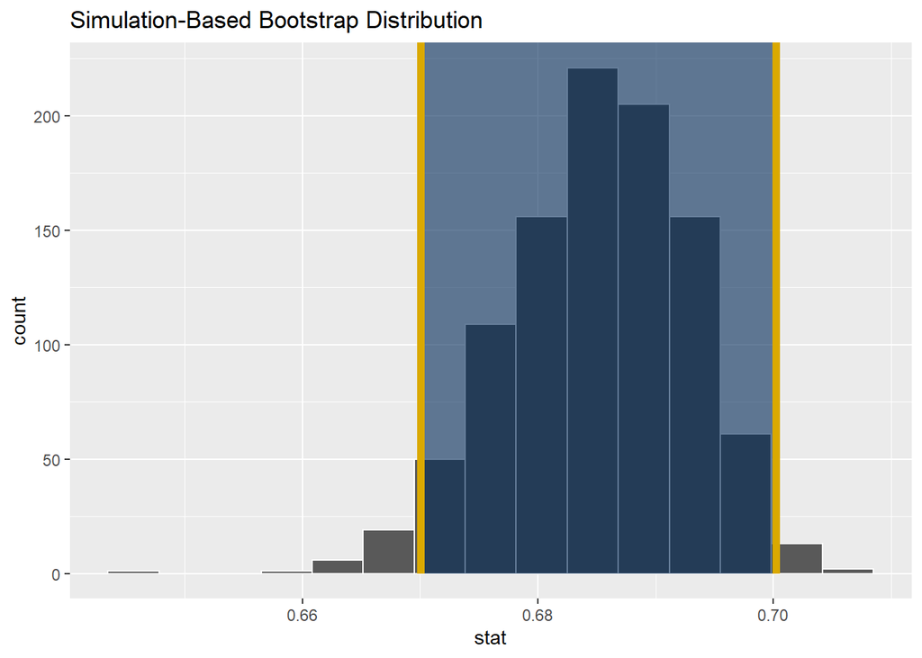

```r
UCM_BS4_2 <- UCM_BS4 %>%
  get_ci(point_estimate = mean(UCM_BS4$stat),
         level = 0.95, type = "se")

visualize(UCM_BS4) +
  shade_ci(endpoints = UCM_BS4_2, color = "#DAA900", fill = "#002856")
```

```r
#Bad Confidence Levels x>60
```

*Confidence Interval for 5th Year Retention Rate

```r
# bootstrap distribution
UCM_BS5<- UCM_Regression %>%
  specify(response = `5th Year Retention Rate`) %>%
  generate(reps = 1000, type = "bootstrap") %>%
  calculate(stat = "mean")
UCM_BS5 %>%
  get_confidence_interval(level = 0.95, type = "percentile")
```

```
## # A tibble: 1 × 2
##   lower_ci upper_ci
##      <dbl>    <dbl>
## 1    0.251    0.294
```

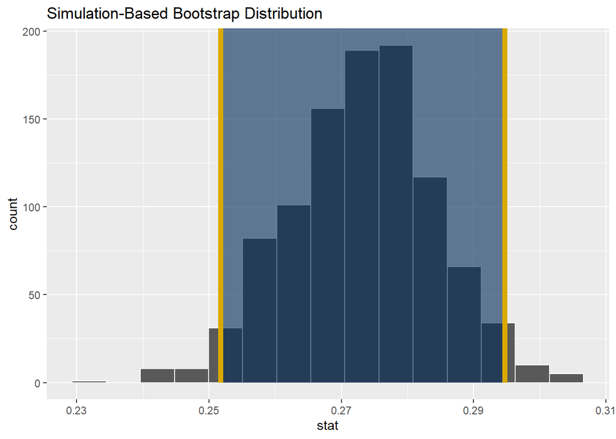

```r
UCM_BS5_2 <- UCM_BS5 %>%
  get_ci(point_estimate = mean(UCM_BS5$stat),
         level = 0.95, type = "se")

visualize(UCM_BS5) +
  shade_ci(endpoints = UCM_BS5_2, color = "#DAA900", fill = "#002856")
```

```r
#Bad Confidence Levels x<50
```

*Confidence Interval for 6th Year Retention Rate

```r
# bootstrap distribution
UCM_BS6 <- UCM_Regression %>%
  specify(response = `6th Year Retention Rate`) %>%
  generate(reps = 1000, type = "bootstrap") %>%
  calculate(stat = "mean")
UCM_BS6 %>%
  get_confidence_interval(level = 0.95, type = "percentile")
```

```
## # A tibble: 1 × 2
##   lower_ci upper_ci
##      <dbl>    <dbl>
## 1   0.0408   0.0623
```

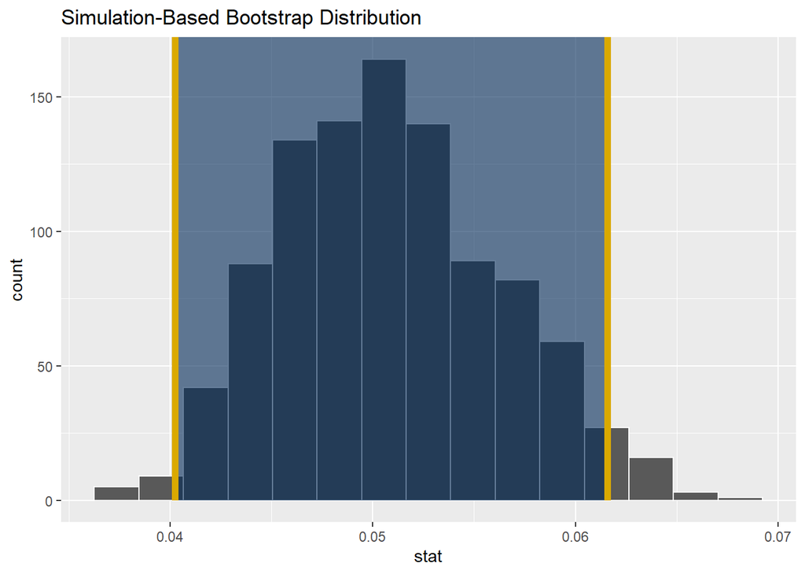

```r
UCM_BS6_2 <- UCM_BS6 %>%
  get_ci(point_estimate = mean(UCM_BS6$stat),
         level = 0.95, type = "se")

visualize(UCM_BS6) +
  shade_ci(endpoints = UCM_BS6_2, color = "#DAA900", fill = "#002856")
```

*Confidence Interval for 2nd Year Graduation Rate

```r
# bootstrap distribution
UCM_BS2g <- UCM_Regression %>%
  specify(response = `2nd Year Graduation Rate`) %>%
  generate(reps = 1000, type = "bootstrap") %>%
  calculate(stat = "mean")
#Bad Confidence Levels x<50
```

```r
UCM_BS2g %>%
  get_confidence_interval(level = 0.95, type = "percentile")
```

```
## # A tibble: 1 × 2
##   lower_ci upper_ci
##      <dbl>    <dbl>
## 1        0        0
```

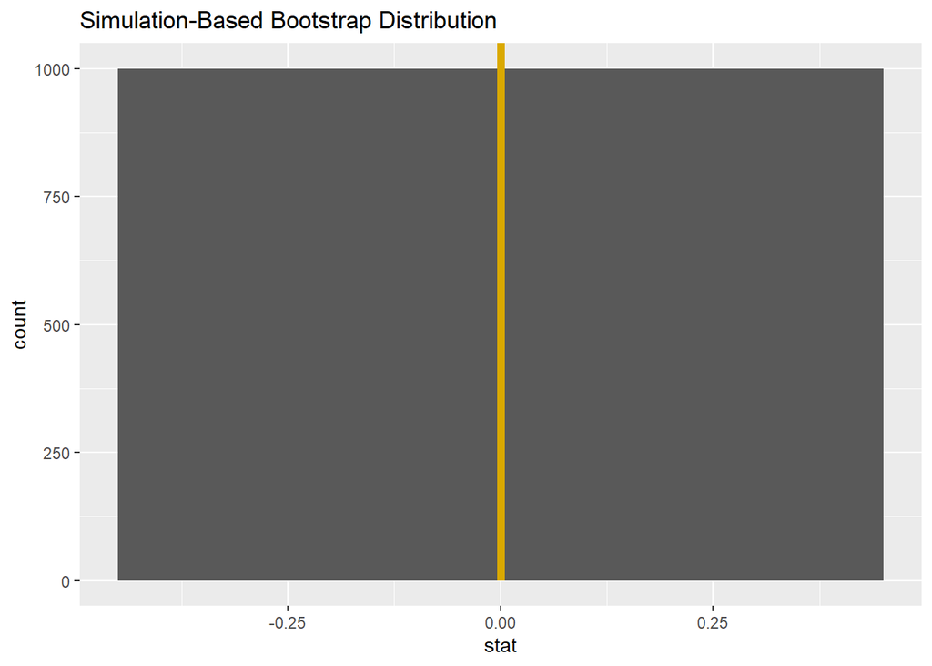

```r
UCM_BS2_1.g <- UCM_BS2g %>%
  get_ci(point_estimate = mean(UCM_BS2g$stat),
         level = 0.95, type = "se")

visualize(UCM_BS2g) +
  shade_ci(endpoints = UCM_BS2_1.g, color = "#DAA900", fill = "#002856")
```

```r
#Definite Bad Confidence Levels x<50
```

*Confidence Interval for 3rd Year Graduation Rate

```r
# bootstrap distribution
UCM_BS3g <- UCM_Regression %>%
  specify(response = `3rd Year Graduation Rate`) %>%
  generate(reps = 1000, type = "bootstrap") %>%
  calculate(stat = "mean")
UCM_BS3g %>%
  get_confidence_interval(level = 0.95, type = "percentile")
```

```
## # A tibble: 1 × 2
##   lower_ci upper_ci
##      <dbl>    <dbl>
## 1   0.0121   0.0186
```

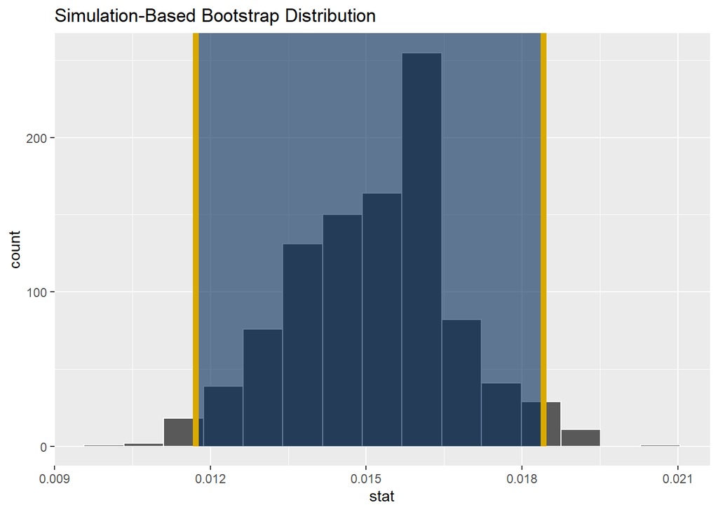

```r
UCM_BS3_2.g <- UCM_BS3g %>%
  get_ci(point_estimate = mean(UCM_BS3g$stat),
         level = 0.95, type = "se")

visualize(UCM_BS3g) +
  shade_ci(endpoints = UCM_BS3_2.g, color = "#DAA900", fill = "#002856")
```